# 11. Exam #3 Review

Cheng Peng

West Chester University

# Review Topics for Midterm Exam #3

## Rules of Derivative

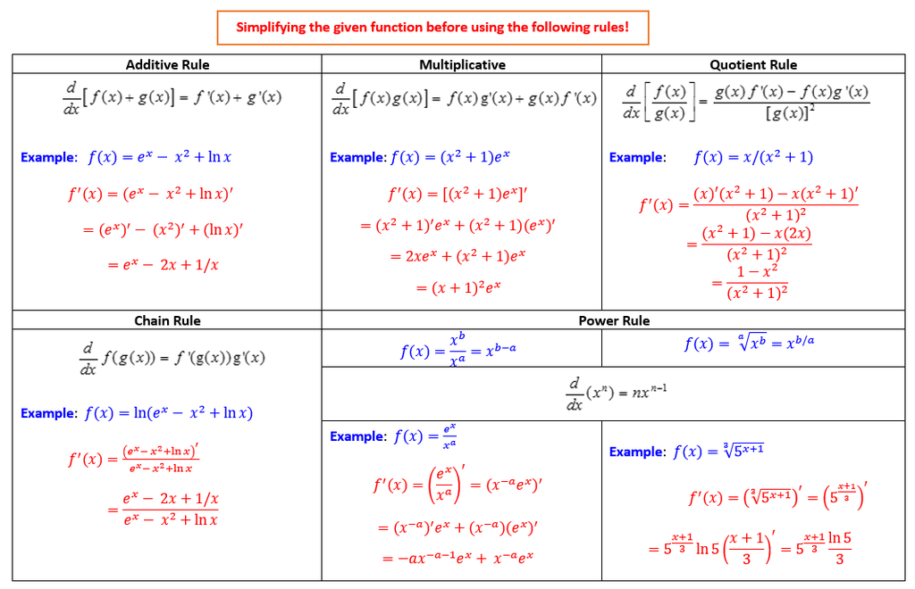

## Optimizations

- Critical Values of a function and first-order derivatives
  - Types of critical values: $f^\prime(x) = 0$ or $f^\prime(x)$ do not exist.

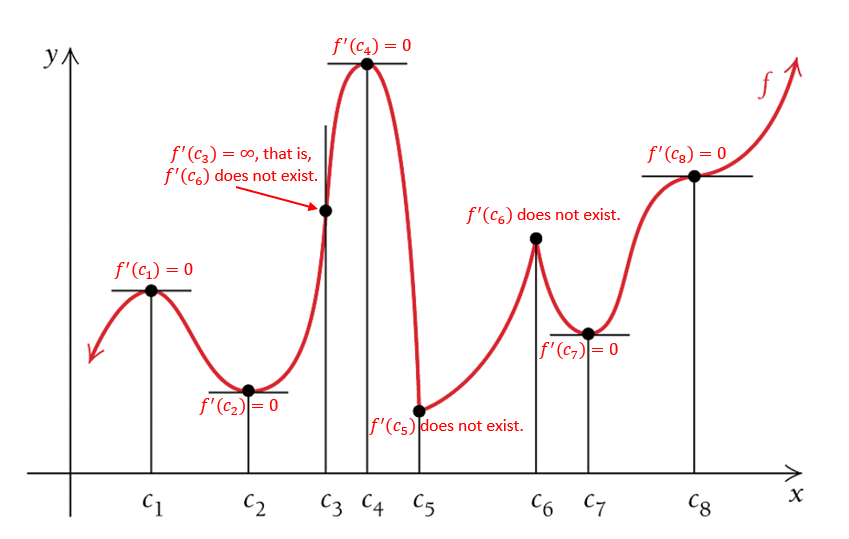

- Relative extrema
  - A critical value may not result in relative extrema

    **Example 2**: See the following figure

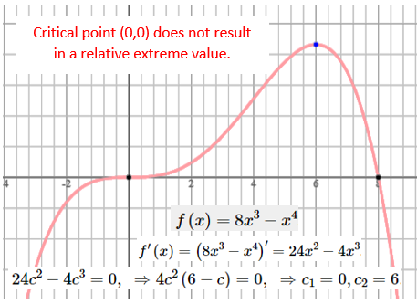

  - Evaluate the function at critical points

  **Example 3** From example 2, we found two critical values $c_1 = 0$ and $c_2 = 6$. Since $c_1 = 0$ is neither a relative minimum nor a relative maximum. $c_2 = 6$ results in a relative maximum (actually the global maximum): $f(6) =8\times 6^3 - 6^4 = 432$.
- Concavity of a function and the second-order derivative
  - Definition of concave up/down of a function over intervals determined by the solutions to $f^{\prime\prime}(x) = 0$.

    **Example 4**: Determine the concavity intervals of $f(x) = x^3-3x^2-1$

    **Solution**: $f^{\prime}(X) = (x^3-3x^2-1)^{\prime} = 3x^2 - 6x$ and $f^{\prime\prime}(x) = (3x^2 - 6x)^\prime = 6x - 6$. Setting $f^{\prime\prime}(x) = 0$, we have $6x-6=0$, which gives $x =1$. Therefore, the inflection point is $(1, -3)$. The concave down interval is $(-\infty, 1)$ and concave up interval $(1, \infty)$.

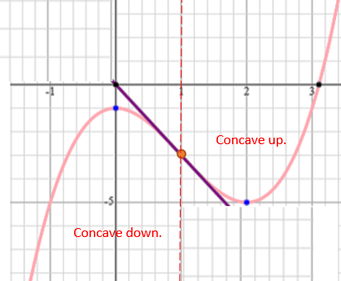

  - Finding absolute maximum and minimum:
    1. identify critical values by (1) solving $f^\prime(x) = 0$; (2) finding $x$ such that $f^\prime(x)$ does not exist.
    2. Evaluate $f(x)$ at all critical values and the end values of interval $[a, b]$
    3. The biggest finite value is the absolute maximum and the smallest finite value is the absolute minimum.

**Example 5**: Find the absolute maximum and minimum of the function $f(x) = x + 2/x$ on the given interval $[0.5, 2]$

**Solution**: *Step 1* - finding critical values. $f^\prime(x) = 1 + 2\times(-x^{-1-1}) = 1-2/x^{-2} = (x^2-2)/2$. $f^\prime(x) = 0$ yields $x^2 -2 = 0$, i.e., $x = \sqrt{2}$ is the only root in $[0.5, 2]$. *Step 2*. Evaluate $f(x)$ at $x = 0.5, \sqrt{2}, 2$: $f(0.5) = 0.5 + 2/0.5 = 4.5$, $f(\sqrt{2}) = \sqrt{2} + 2/\sqrt{2} = 2\sqrt{2} \approx 2.83$, and $f(2) = 2 + 2/2 = 3$. *Step 3*: The absolute maximum of $f(x)$ on $[0.5, 2]$ is attained at $x = 0.5$ and $f_{\text{maximum}}(0.5) = 4.5$ and the absolute minimum is attained at $x = \sqrt{2}$ and $f_{\text{maximum}}(\sqrt{2}) \approx 2.83$.

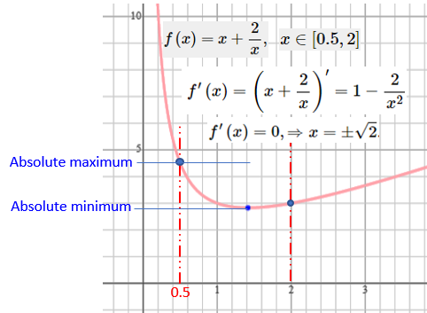

- Implicit differentiation
  - Implicit function:

    **Example 6**: If $y = f(x)$ is defined implicitly by equation $F(x,y) = x^3 + y^3 - 3x^2y^5 = 0$, then function $y = f(x)$ is called implicit function.
  - Derivative of implicit functions: Finding the derivative of an implicit function involves two basic steps- (1). Differentiate both sides of the equation with respect to $x$, assuming that $y$ is a differentiable function of $x$ and using the chain rule; (2). Solve the resulting equation for the derivative $y^\prime$.

    **Example 7** $y$ is implicitly defined in equation $x^3 + 2y^3 + yx^2 = 3$. Find $y^\prime$.

  **Solution**: $(x^3 + 2y^3 + yx^2)^\prime = 3^\prime ~~\Rightarrow~~~ (x^3)^\prime + 2(y^3)^\prime + (yx^2)^\prime = 3$. Note that the second and third terms on the left-hand side call for the chain rule: $3x^2 + 3y^2 y^\prime + [y^\prime x^2 + y(x^2)^\prime] = 0$, which is equivalent to $3x^2 + 3y^2 y^\prime + y^\prime x^2 + 2xy = 0$. Solve for $y^\prime$ from this equation, we have $y^\prime = (3x^2 + 2yx)/(x^2 + 6y^2)$.
  - Applications of the method of implicit differentiation

## Applications

- Cost, revenue, and profit functions
  - The relationship between the three functions $P(x) = R(x) - C(x)$
  - Average cost, revenue, and profit functions
    $$\overline{C(x)} = \frac{C(x)}{x}, ~~~~ \overline{R(x)} =
    \frac{R(x)}{x}, ~~~~~~~\text{and}~~~ \overline{P(x)} = \frac{P(x)}{x}$$

    **Example 8**: The cost, in thousands of dollars, for producing $x$ thousand cellphone cases is given by $C(x)=22+x-0.004x^2$. Find the average cost function.

    **Solution**: By the definition, the average cost is defined to be $\overline{C(x)} = C(x)/x = (22+x-0.004x^2)/x = 22/x + 1 -0.004x$.
- Definitions of average cost, revenue, and profit functions
- Definitions of marginal cost, revenue, and profit functions: the marginal functions are defined to be of the following form

$$\text{MC}(x) \approx C^\prime(x),~~~
\text{MR}(x) \approx R^\prime(X), ~~\text{and}~~ \text{MP}(x) =
P^\prime(x)$$

- Maximization and minimization of cost, revenue, and profit functions

**Example 10**: The average cost for making $q$ items of certain product is given by $\text{AC} = 2x - 11 + 50/x$. Find the minimum average cost on ver interval $(0, \infty)$.

**Solution** Set $[\text{AC}]^\prime = 2 - \frac{50}{x^2} = 0$, we have $2x^2 -50 = 0$ which is equivalent to $(5x)(x+5) = 0$. Since the average price is positive, the critical of the average cost over interval $(0, \infty)$ is $c = 5$. Note that $[AC]^{\prime\prime} = - [50x^{-2}]^\prime = 100x^{-3} > 0$. Therefore, the absolute minimum average cost is minimized at $x = 5$. The minimum cost is $\text{AC}(5) = 10-11+50/5 = 9$.

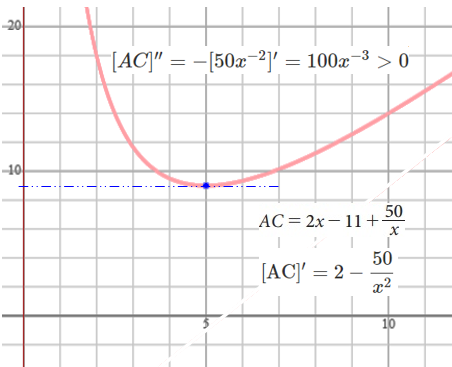

- Elastic Demand: **See the examples in the last lecture note**.
  - Percentage change = (new - old)/old

    **Example 11**: The price of a toy car is decreased from $20 to $15 after a discount. Find the percentage change in the amount.

    **Solution**: percentage change in the price = (15-20)/20 = -0.25.
  - Demand function: $q = D(p)$, $p$ is the unit price. For example, $D(p) = 280-7p$.
  - Elastic demand = - (percentage change in demand)/(percentage change in price)
  - Elastic demand $= -\frac{xD^\prime(x)}{D(x)}$

  **Example 12**: The demand for organic chewing gum is given by $q = D(x) = 30 -5x$. Find the elasticity of demand as a function of x.

  **Solution**: Note that $D^\prime(x) = -5$. By the definition, $E(x) = -xD^\prime(x)/D(x) = 5x/(30-5x) = x/(6-x)$.